# Lab 4 (Lecture 12) - Text Classification

[figure not shown]

## Social Media Data Analysis - A.A. 2023-2024

### Text Analysis (NLP) - Classification

Francesco Ragusa https://iplab.dmi.unict.it/ragusa/ - francesco.ragusa@unict.it

In this laboratory, we will see the step by step process of how we can do text classification exploiting the FAISS library.

- The classification problem can be divided into the following steps:
  - Setup;
  - Loading the Dataset;
  - Text pre-processing;
  - Vectorization;
  - Classifiers and Results;

```python
import pandas as pd
import numpy as np
#for text pre-processing
import re, string
import nltk
from nltk.tokenize import word_tokenize
from nltk.corpus import stopwords
from nltk.tokenize import word_tokenize
from nltk.stem import SnowballStemmer
from nltk.corpus import wordnet
from nltk.stem import WordNetLemmatizer
nltk.download('punkt')
nltk.download('averaged_perceptron_tagger')
nltk.download('wordnet')
nltk.download('stopwords')
#for model-building
from sklearn.model_selection import train_test_split
from sklearn.naive_bayes import MultinomialNB
from sklearn.metrics import classification_report, f1_score, accuracy_score, confusion_matrix
from sklearn.metrics import roc_curve, auc, roc_auc_score
# bag of words
from sklearn.feature_extraction.text import TfidfTransformer
from sklearn.feature_extraction.text import CountVectorizer
#for word embedding
import gensim
from gensim.models import Word2Vec
```

# 2. Loading the Dataset

The data set that we will be using for this article is the “Natural Language Processing with Disaster Tweets” data set where we’ll be predicting whether a given tweet is about a real disaster (target=1) or not (target=0).

The ubiquitousness of smartphones enables people to announce an emergency they’re observing in real-time. Because of this, more agencies are interested in programatically monitoring Twitter (i.e. disaster relief organizations and news agencies).

But, it’s not always clear whether a person’s words are actually announcing a disaster. Take this example:

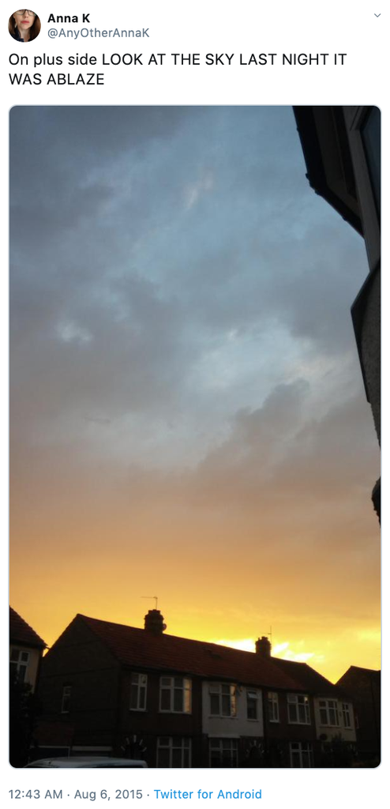

The author explicitly uses the word “ABLAZE” but means it metaphorically. This is clear to a human right away, especially with the visual aid. But it’s less clear to a machine.

```python
train= pd.read_csv('train.csv')
test=pd.read_csv('test.csv')
```

- id: a unique identifier of every tweet
- keyword: a particular keyword from the tweet (this can be blank)
- location: the location the tweet was sent from (this can be blank)
- text: the text of the tweet
- target: present only in the train data, and denotes if the tweet is about a real disaster (1) or not (0)

```python
train.sample(50)
```

|  | id | keyword | location | text | target |
| --- | --- | --- | --- | --- | --- |
| 6879 | 9862 | traumatised | uk | go easy on her paul the poor woman has been tr... | 0 |
| 4253 | 6043 | heat%20wave | NaN | Japan Heat Wave Intensifies ÛÒ Death Toll Sur... | 1 |
| 4350 | 6178 | hijack | Miami, Florida | Tension In Bayelsa As Patience Jonathan Plans ... | 1 |
| 3918 | 5573 | flood | NaN | It's been raining since you left me\nNow I'm d... | 0 |
| 3112 | 4466 | electrocuted | North Carolina | I'm loving this classic barn shot! We may or m... | 1 |
| 1285 | 1853 | burned | NaN | My sister Rl Burned All Her Boyfriend Clothes ... | 0 |
| 5721 | 8164 | rescuers | NaN | VIDEO: 'We're picking up bodies from water': R... | 1 |
| 2788 | 4011 | disaster | Manila, Philippines | Strengthening partnerships #AfterHaiyan http:/... | 1 |
| 6690 | 9585 | thunder | Palm Desert, CA | The Flash And The Thunder by WC Quick on Amazo... | 0 |
| 7358 | 10535 | windstorm | Galveston, Texas | For sixth year in a row premium costs for wind... | 0 |
| 5434 | 7753 | police | NaN | Police unions retard justice &amp; drain gov $... | 0 |
| 1274 | 1836 | burned | NaN | All you have to do is look up sports riots on ... | 1 |
| 1855 | 2667 | crush | NaN | I'm my own woman crush ???? | 0 |
| 388 | 561 | arson | Kingston, Pennsylvania | The Sound of Arson | 0 |
| 5118 | 7299 | nuclear%20reactor | Washington, D.C. | Global Nuclear Reactor Construction Market gre... | 1 |
| 1244 | 1792 | buildings%20on%20fire | Fort Walton Beach, Fl | They are evacuating buildings in that area of ... | 1 |
| 5057 | 7206 | natural%20disaster | NaN | RaÌ¼l sends a message of condolence to Vietnam... | 1 |
| 3900 | 5547 | flattened | Lubbock, Texas | @SeanPeconi @Jason_Floyd @LynchOnSports @crisc... | 0 |
| 775 | 1122 | blew%20up | NaN | Did anyone else see that fireball falling to e... | 1 |
| 5000 | 7132 | military | NY | 13 reasons why we love women in the military ... | 0 |
| 1839 | 2644 | crashed | i love the smurfs 2 | Honestly nightmarish. God driving to new place... | 0 |
| 6289 | 8985 | storm | Cleveland, OH - San Diego, CA | #NASA announced that a massive #solar storm is... | 1 |
| 4861 | 6920 | mass%20murderer | Haysville, KS | @bettyfreedoms @AbnInfVet hillary mass murderer. | 1 |
| 698 | 1005 | blazing | NaN | I'm blazing rn and there's nothing you can do ... | 0 |
| 3025 | 4343 | dust%20storm | NaN | Severe storm weakening as it moves SE towards ... | 1 |
| 177 | 253 | ambulance | NaN | Twelve feared killed in Pakistani air ambulanc... | 1 |
| 514 | 740 | attacked | SÌ£o Paulo SP, Brasil | Christian Attacked by Muslims at the Temple Mo... | 1 |
| 3486 | 4983 | explosion | Columbus, OH | A Pyrotechnic Artwork by Cai Guo-Qiang Explode... | 1 |
| 6636 | 9503 | terrorist | Beit El - Israel | 'The Terrorist Tried to Get Out of the Car; I ... | 1 |
| 2904 | 4171 | drown | NaN | @jasminehuerta24 I hope you drown ?? | 0 |
| 2176 | 3119 | debris | Campo Grande-MS | [Reuters] Debris confirmed from MH370; relativ... | 1 |
| 1146 | 1650 | bombing | SWMO | Japan Marks 70th Anniversary of Hiroshima Atom... | 1 |
| 6611 | 9467 | terrorism | NaN | Pakistan's Supreme Court rules to allow milita... | 1 |
| 5028 | 7169 | mudslide | the burrow | DORETTE THATS THE NAME OF THE MUDSLIDE CAKE MAKER | 0 |
| 4211 | 5982 | hazard | ilford | Fair enough we have two of the best attacking ... | 0 |
| 4715 | 6703 | lava | NaN | My hands are cold but my feet are warm. That's... | 0 |
| 1832 | 2633 | crashed | Gujranwala, Pakistan | Maj Muzzamil Pilot Offr of MI-17 crashed near ... | 1 |
| 787 | 1141 | blight | IJmuiden, The Netherlands | New post: Prysmian secures contract for Blight... | 0 |
| 2362 | 3398 | demolition | NaN | 7 Christians detained in Zhejiang amid widespr... | 0 |
| 7334 | 10499 | wildfire | Ashland, Oregon | Be ember aware! http://t.co/LZmL1xB2nH | 1 |
| 1009 | 1464 | body%20bagging | NaN | @MzGracieBaby for the record im jumpin out the... | 0 |
| 2354 | 3389 | demolition | ÌÏT: 36.142163,-95.979189 | @samajp32 really needs to tone it down some in... | 0 |
| 3601 | 5141 | fatal | Jaipur, Rajasthan, India | Success is not permanent &amp; failure is not ... | 0 |
| 3965 | 5634 | flooding | Miami Beach, Fl | The Chinese are flooding NYC market like never... | 0 |
| 6027 | 8613 | seismic | NaN | SEISMIC AUDIO SA-15T SA15T Padded Black Speake... | 0 |
| 3301 | 4731 | evacuate | NaN | Condemnation clearly replacing the latest resp... | 1 |
| 5580 | 7962 | razed | Nigeria | TENSION IN ABIA AS INEC OFFICEÛªS RAZEDåÊÛÒ ... | 1 |
| 523 | 755 | avalanche | Ireland | A little piece I wrote for the Avalanche Desig... | 0 |
| 4158 | 5907 | harm | NaN | @angel_star39 Obama should feel responsible br... | 0 |
| 7109 | 10186 | violent%20storm | South Africa | POV footage captures violent landing from insi... | 1 |

## 3. Data Exploration

## 3.1 Class Distribution

Let's explore the class distribution of the dataset showing it through a barplot using the seaborn library:

```
0    4342
1    3271
Name: target, dtype: int64
```

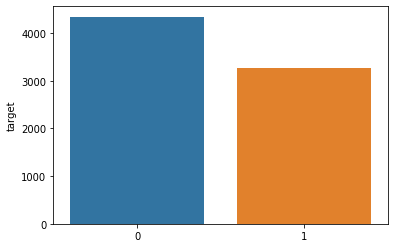

```python
%matplotlib inline
import seaborn as sns

x=train['target'].value_counts()
print(x)
sns.barplot(x.index,x)
```

There are more tweets with class 0 (no disaster) than class 1 (disaster tweets). We can say that the dataset is relatively balanced with 4342 non-disaster tweets (57%) and 3271 disaster tweets (43%).

**Question 1**

The dataset is balanced. Why is this something we should keep in mind?

**Answer 1**

Now, we search if the dataframe contains some `missing values`:

```python
train.isna().sum()
```

```
id             0
keyword       61
location    2533
text           0
target         0
dtype: int64
```

We have ~2.5k missing values in `location` field and 61 missing values in `keyword` column.

## 3.2 Number of words and characters

Let's verify how many words are contained in a tweet to understand if a class contains more words to another.

```python
train['word_count'] = train['text'].apply(lambda x: len(str(x).split()))
print(train[train['target']==1]['word_count'].mean()) #Disaster tweets
print(train[train['target']==0]['word_count'].mean()) #Non-Disaster tweets
```

```
15.167532864567411
14.704744357438969
```

The average number of words in a disaster tweet is 15.17 as compared to an average of 14.7 words in a non-disaster tweet. Let's plot the words distribution for all the tweets through the matplotlib library:

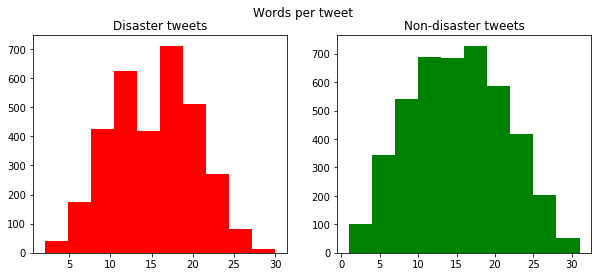

```python
from matplotlib import pyplot as plt

fig,(ax1,ax2)=plt.subplots(1,2,figsize=(10,4))
train_words=train[train['target']==1]['word_count']
ax1.hist(train_words,color='red')
ax1.set_title('Disaster tweets')
train_words=train[train['target']==0]['word_count']
ax2.hist(train_words,color='green')
ax2.set_title('Non-disaster tweets')
fig.suptitle('Words per tweet')
plt.show()
```

**Question 2**

The word distribution in a tweet it seems to be similar for both classes. Can be used as a significative feature to consider to perform binary classification? Why?

**Answer 2**

Let's check the number of characters which compose a tweet:

```python
train['char_count'] = train['text'].apply(lambda x: len(str(x)))
print(train[train['target']==1]['char_count'].mean()) #Disaster tweets
print(train[train['target']==0]['char_count'].mean()) #Non-Disaster tweets
```

```
108.11342097217977
95.70681713496084
```

The average characters in a disaster tweet is 108.1 as compared to an average of 95.7 characters in a non-disaster tweet.

Let's plot the character distribution for all the tweets:

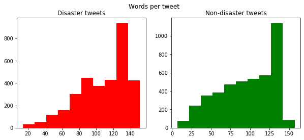

```python
fig,(ax1,ax2)=plt.subplots(1,2,figsize=(10,4))
train_words=train[train['target']==1]['char_count']
ax1.hist(train_words,color='red')
ax1.set_title('Disaster tweets')
train_words=train[train['target']==0]['char_count']
ax2.hist(train_words,color='green')
ax2.set_title('Non-disaster tweets')
fig.suptitle('Words per tweet')
plt.show()
```

## 4 Text pre-processing

Before we move to perform classification, we need to preprocess our dataset by removing punctuations and special characters, cleaning texts, removing stop words, and applying lemmatization.

In particular, we will apply the following operations:

## 4.1 Lowercasing

Converting the text into lowercase is an essential step in any NLP project.

This can be done using the `apply()` methods of pandas library. It is important to pay attention to the fact that the `keyword` and `location` columns contain missing values (i.e.: values that are NA such as numpy.nan or None); to avoid an unexpected error, `pd.isna()` method is used to skip empty entries. We will store the clean text in a new column.

```python
train["keyword"] = train["keyword"].apply(lambda x: str.lower(x) if pd.isna(x) != True else x)
train["location"] = train["location"].apply(lambda x: str.lower(x) if pd.isna(x) != True else x)
train["clean_text"] = train["text"].apply(lambda x: str.lower(x))
```

```python
train.sample(5)
```

|  | id | keyword | location | text | target | word_count | char_count | clean_text |
| --- | --- | --- | --- | --- | --- | --- | --- | --- |
| 826 | 1202 | blizzard | NaN | Tomorrow's Announcement VODs http://t.co/cUbze... | 0 | 4 | 51 | tomorrow's announcement vods http://t.co/cubze... |
| 7448 | 10659 | wounds | NaN | 11 puncture wounds | 0 | 3 | 18 | 11 puncture wounds |
| 4835 | 6882 | mass%20murder | new sweden | The media needs to stop publicizing mass murde... | 0 | 22 | 135 | the media needs to stop publicizing mass murde... |
| 5245 | 7501 | oil%20spill | united kingdom | LA Times: Refugio oil spill may have been cost... | 1 | 13 | 95 | la times: refugio oil spill may have been cost... |
| 2779 | 3996 | devastation | NaN | Water now tops the charts for highest global r... | 1 | 22 | 141 | water now tops the charts for highest global r... |

**Question 3**

Why are we converting words to lowercase? What's happens if we represent in a vector space model the words `Data`, `data` and `DATA` without applying a lowercasing operation?

**Answer 3**

## 4.2 URL links, Entities and Punctuation Removal

Since the dataset is based on tweets, it may include a lot of URL links such as http://t.co/gkNRP0e8Qs. We can easily do this exploiting regular expressions through the regex library. In particular the sub() function, offered by the re module, can be used to replace URL links with blank as follows:

```python
train["keyword"] = train["keyword"].apply(lambda x: re.sub(r'http\S+|www\S+','',x) if pd.isna(x) != True else x)
train["location"] = train["location"].apply(lambda x: re.sub(r'http\S+|www\S+','',x) if pd.isna(x) != True else x)
train["clean_text"] = train["clean_text"].apply(lambda x: re.sub(r'http\S+|www\S+','',x))
```

```python
train.sample(25)
```

|  | id | keyword | location | text | target | word_count | char_count | clean_text |
| --- | --- | --- | --- | --- | --- | --- | --- | --- |
| 6696 | 9593 | thunder | palma, islas baleares | @AsimTanvir @NemesisK_PES @KevR_7 Snow? Thund... | 1 | 7 | 63 | @asimtanvir @nemesisk_pes @kevr_7 snow? thund... |
| 2363 | 3400 | demolition | san jose | San Jose: Demolition of Willow Glen Trestle pu... | 0 | 14 | 103 | san jose: demolition of willow glen trestle pu... |
| 421 | 611 | arsonist | [ blonde bi fry. ] | 'wHeRE's mY aRsOnISt aT???' | 0 | 4 | 27 | 'where's my arsonist at???' |
| 655 | 947 | blaze | ducked off . . . | niggas love hating. | 0 | 3 | 19 | niggas love hating. |
| 3742 | 5319 | fire | 2 high 2 come down | @Miss_HoMaStToPa cause were on fire we are on ... | 1 | 25 | 124 | @miss_homasttopa cause were on fire we are on ... |
| 6792 | 9731 | tragedy | NaN | Rly tragedy in MP: Some live to recount horror... | 1 | 23 | 137 | rly tragedy in mp: some live to recount horror... |
| 6183 | 8825 | sirens | nanaimo, bc, canada | Photoset: hakogaku: ?åÊI am a kurd. i was born... | 1 | 19 | 130 | photoset: hakogaku: ?åêi am a kurd. i was born... |
| 6853 | 9822 | trauma | NaN | Hiroshima: They told me to paint my story: Eig... | 1 | 21 | 136 | hiroshima: they told me to paint my story: eig... |
| 5747 | 8205 | riot | world wide web | To All The Meat-Loving Feminists Of The World ... | 0 | 12 | 92 | to all the meat-loving feminists of the world ... |
| 2272 | 3259 | demolish | eastbourne england | Doone Silver Architects has won permission to ... | 0 | 21 | 141 | doone silver architects has won permission to ... |
| 5935 | 8476 | screamed | 1d \| 5sos \| ag | I JUST SCREAMED IN 57 LANGUAGES THIS IS SO GOO... | 0 | 11 | 71 | i just screamed in 57 languages this is so good |
| 4436 | 6312 | hostage | global | The horrific story of being a hostage - The ho... | 1 | 22 | 130 | the horrific story of being a hostage - the ho... |
| 2101 | 3018 | death | NaN | I tell my cousins I don't wanna hang out and t... | 0 | 24 | 118 | i tell my cousins i don't wanna hang out and t... |
| 2162 | 3102 | deaths | top secret bunker | @MayorofLondon pls reduce cyclist deaths with ... | 1 | 21 | 140 | @mayoroflondon pls reduce cyclist deaths with ... |
| 548 | 797 | battle | NaN | CIVIL WAR GENERAL BATTLE BULL RUN HERO COLONEL... | 1 | 16 | 126 | civil war general battle bull run hero colonel... |
| 2417 | 3476 | derailed | washington, dc | #Metro still doesn't know when Blue &amp; Oran... | 1 | 24 | 142 | #metro still doesn't know when blue &amp; oran... |
| 2046 | 2936 | danger | atlanta georgia | @nuggets #FETTILOOTCH IS #SLANGLUCCI OPPRESSIO... | 0 | 12 | 111 | @nuggets #fettilootch is #slanglucci oppressio... |
| 4974 | 7092 | meltdown | washington, dc | President Barack Obama has on air meltdown ove... | 1 | 16 | 119 | president barack obama has on air meltdown ove... |
| 6695 | 9592 | thunder | NaN | That was the l9udest thunder I've ever heard | 0 | 8 | 45 | that was the l9udest thunder i've ever heard |
| 6573 | 9406 | survivors | sì£o paulo, brasil | Hiroshima survivors fight nuclear industry in ... | 1 | 10 | 85 | hiroshima survivors fight nuclear industry in ... |
| 1681 | 2425 | collide |  | I liked a @YouTube video from @gassymexican ht... | 0 | 16 | 125 | i liked a @youtube video from @gassymexican w... |
| 1690 | 2440 | collide | pennsylvania, usa | Worlds Collide When an American Family Takes O... | 0 | 21 | 137 | worlds collide when an american family takes o... |
| 4967 | 7078 | meltdown | the shores of lake kilby | Ever since my Facebook #Mets meltdown after th... | 0 | 15 | 91 | ever since my facebook #mets meltdown after th... |
| 4771 | 6789 | lightning | reddit | Lightning strike in the distance via /r/pics h... | 1 | 9 | 73 | lightning strike in the distance via /r/pics ... |
| 6766 | 9697 | tornado | NaN | @Ayshun_Tornado then don't | 0 | 3 | 26 | @ayshun_tornado then don't |

In addition, tweets contain a lot of mentions (e.g.: @RyleeDowns02) and hashtags (e.g.: #CAfire). We can remove them by creating a function as shown below:

```python
import re, string

def remove_entities (text):
    entity_prefixes = ['@', '#']
    for separator in string.punctuation:
        if separator not in entity_prefixes:
            text = text.replace(separator, '')
    words = []
    for word in text.split():
        word = word.strip()
        if word:
                if word[0] not in entity_prefixes:
                    words.append(word)
    return ' '.join(words)
```

Now, we apply the function to our Training set:

```python
train["keyword"] = train["keyword"].apply(lambda x: remove_entities(x) if pd.isna(x) != True else x)
train["location"] = train["location"].apply(lambda x: remove_entities(x) if pd.isna(x) != True else x)
train["clean_text"] = train["clean_text"].apply(lambda x: remove_entities(x))
```

```python
train.sample(25)
```

|  | id | keyword | location | text | target | word_count | char_count | clean_text |
| --- | --- | --- | --- | --- | --- | --- | --- | --- |
| 2890 | 4153 | drown | NaN | 'Save me from my self don't let me drown'. | 0 | 9 | 42 | save me from my self dont let me drown |
| 5444 | 7765 | police | portland or | UNWANTED PERSON at 200 BLOCK OF SE 12TH AVE PO... | 0 | 16 | 102 | unwanted person at 200 block of se 12th ave po... |
| 1204 | 1733 | buildings20burning | st charles md | I'm mentally preparing myself for a bomb ass s... | 0 | 17 | 93 | im mentally preparing myself for a bomb ass sc... |
| 5770 | 8237 | riot | tipperary long way | Sweetpea's are running riot at the allotment -... | 1 | 15 | 100 | sweetpeas are running riot at the allotment an... |
| 7584 | 10837 | NaN | NaN | These boxes are ready to explode! Exploding Ki... | 0 | 13 | 127 | these boxes are ready to explode exploding kit... |
| 5452 | 7774 | police | NaN | @robbiewilliams U fkn asswipe playing for Isra... | 1 | 16 | 98 | u fkn asswipe playing for israeli child killer... |
| 5506 | 7857 | quarantined | NaN | Here we go again. EBOLA! Run for your lives! a... | 1 | 11 | 81 | here we go again ebola run for your lives aaar... |
| 2564 | 3679 | destroy | new england | 5/6 will destroy Reg C competitiveness. The ... | 1 | 21 | 137 | 56 will destroy reg c competitiveness the enti... |
| 2954 | 4245 | drowned | tampa | .@DinosaurDracula Felt remorse for missing Pam... | 0 | 18 | 133 | felt remorse for missing pam drowned it with t... |
| 2705 | 3887 | detonation | NaN | Ignition Knock (Detonation) Sensor ACDelco GM ... | 0 | 11 | 119 | ignition knock detonation sensor acdelco gm or... |
| 5087 | 7254 | nuclear20disaster | new york ny | Physical sense helps preserve memories of 2011... | 1 | 15 | 126 | physical sense helps preserve memories of 2011... |
| 2001 | 2877 | damage | marysville mi | Let's say a tree falls on your fence. Do you k... | 0 | 19 | 135 | lets say a tree falls on your fence do you kno... |
| 1768 | 2541 | collision | vancouver | 7:13pm #MAPLERIDGE Lougheed Hwy EB is closed b... | 1 | 24 | 137 | 713pm lougheed hwy eb is closed between 203rd ... |
| 6175 | 8806 | sirens | victoria mozì£o | To ouvindo sleeping with sirens awn | 0 | 6 | 35 | to ouvindo sleeping with sirens awn |
| 6759 | 9684 | tornado | providence ri lisnaskea | Still can't get over the thunderstorm/tornado ... | 1 | 21 | 137 | still cant get over the thunderstormtornado we... |
| 6834 | 9788 | trapped | åålos mina cityã¢ | Hollywood Movie About Trapped Miners Released ... | 0 | 17 | 136 | hollywood movie about trapped miners released ... |
| 6583 | 9422 | survivors | upstairs | The second part which focuses on the survivors... | 1 | 21 | 116 | the second part which focuses on the survivors... |
| 2882 | 4142 | drought | los angeles | We happily support mydrought a project bringi... | 1 | 16 | 121 | we happily support mydrought a project bringin... |
| 7023 | 10067 | typhoon | ngapain | Obama Declares Disaster for Typhoon-Devastated... | 1 | 15 | 136 | obama declares disaster for typhoondevastated ... |
| 3139 | 4511 | emergency | phoenix | God forbid anyone in my family knows how to an... | 0 | 17 | 90 | god forbid anyone in my family knows how to an... |
| 6814 | 9761 | trapped | call me peach or sam lo | IM TRAPPED IN THE DAMN GAS PUMP THERE ARE TWO ... | 0 | 17 | 84 | im trapped in the damn gas pump there are two ... |
| 188 | 267 | ambulance | williamstown vt | @TheNissonian @RejectdCartoons nissan are you ... | 0 | 21 | 121 | nissan are you ok do you need medical assistan... |
| 1120 | 1615 | bombed | stockton on tees teesside uk | @antpips67 @JohnEJefferson obviously I'm aware... | 1 | 21 | 127 | obviously im aware that not all as are from co... |
| 1163 | 1675 | bridge20collapse | NaN | Sioux City Fire Officials Believe Bridge Colla... | 1 | 18 | 136 | sioux city fire officials believe bridge colla... |
| 5021 | 7161 | mudslide | NaN | God bless you and your mudslide cake Dorret ???? | 0 | 9 | 48 | god bless you and your mudslide cake dorret |

In addition, it is possible to remove the punctuation.

```python
train["keyword"] = train["keyword"].apply(lambda x: re.sub(r'[^\w\s]','',x) if pd.isna(x) != True else x)
train["location"] = train["location"].apply(lambda x: re.sub(r'[^\w\s]','',x) if pd.isna(x) != True else x)
train["clean_text"] = train["clean_text"].apply(lambda x: re.sub(r'[^\w\s]','',x))
```

```python
train.sample(25)
```

|  | id | keyword | location | text | target | word_count | char_count | clean_text |
| --- | --- | --- | --- | --- | --- | --- | --- | --- |
| 7043 | 10090 | typhoon | evergreen colorado | Satellite Spies Super Typhoon Soudelor from Sp... | 0 | 9 | 80 | satellite spies super typhoon soudelor from sp... |
| 1053 | 1522 | body20bags | NaN | Womens Handbags Cross Body Geometric Pattern S... | 0 | 13 | 124 | womens handbags cross body geometric pattern s... |
| 1154 | 1662 | bombing | north east usa | What it was like to survive the atomic bombing... | 1 | 12 | 82 | what it was like to survive the atomic bombing... |
| 1917 | 2758 | curfew | antioch california | @michelleellle ?? shut up freshman its past ur... | 0 | 27 | 142 | shut up freshman its past ur curfew u need som... |
| 7543 | 10784 | wreckage | mumbai | Wreckage 'Conclusively Confirmed' as From MH37... | 1 | 17 | 136 | wreckage conclusively confirmed as from mh370 ... |
| 6243 | 8916 | snowstorm | this is paradise relax | ÛÏ@LordBrathwaite: Everyone Here: Ahh I hate ... | 1 | 15 | 112 | ûïlordbrathwaite everyone here ahh i hate snow... |
| 5945 | 8491 | screamed | NaN | i dont even remember slsp happening i just rem... | 0 | 24 | 134 | i dont even remember slsp happening i just rem... |
| 1935 | 2783 | curfew | uganda | @DavisKawalya I know @Mauryn143 will be saying... | 0 | 26 | 139 | i know will be saying her final goodbyes to gr... |
| 1998 | 2872 | damage | indonesia | 'Mages of Fairy Tail.. Specialize in property ... | 0 | 11 | 71 | mages of fairy tail specialize in property dam... |
| 2925 | 4204 | drowned | alberta va | http://t.co/MoA0q0AuFa Jacksonville family ban... | 0 | 16 | 136 | jacksonville family bands together as memorial... |
| 6437 | 9210 | suicide20bombing | usa | Turkish troops killed in Kurdish militant 'sui... | 1 | 9 | 81 | turkish troops killed in kurdish militant suic... |
| 467 | 675 | attack | online 247 not even kidding | Notley's tactful yet very direct response to H... | 1 | 18 | 138 | notleys tactful yet very direct response to ha... |
| 6308 | 9016 | stretcher | NaN | The '1pack 2pack 3pack' line is on fleek if St... | 0 | 12 | 62 | the 1pack 2pack 3pack line is on fleek if stre... |
| 2460 | 3528 | derailment | los angeles | @AlvinNelson07 A train isn't made to withstand... | 1 | 13 | 101 | a train isnt made to withstand collisions imme... |
| 220 | 313 | annihilated | NaN | Cop pulls drunk driver to safety SECONDS befor... | 1 | 18 | 136 | cop pulls drunk driver to safety seconds befor... |
| 7363 | 10543 | windstorm | NaN | IJ: Texas Seeks Comment on Rules for Changes t... | 1 | 12 | 88 | ij texas seeks comment on rules for changes to... |
| 6150 | 8775 | siren | massachusetts usa | @EnvySeven My beautiful Aquarius queenmy Siren... | 0 | 20 | 136 | my beautiful aquarius queenmy siren of the cli... |
| 5095 | 7267 | nuclear20disaster | NaN | The people who tweet and care about #Japan #Fu... | 1 | 21 | 124 | the people who tweet and care about nuclear di... |
| 3253 | 4674 | engulfed | newcastle | Why are you engulfed by low self-image? Take t... | 0 | 12 | 100 | why are you engulfed by low selfimage take the... |
| 4702 | 6686 | landslide | egypt | Italy: Three dead after landslide in the Itali... | 1 | 12 | 90 | italy three dead after landslide in the italia... |
| 247 | 352 | annihilation | wild wild web | annihilating quarterstaff of annihilation | 1 | 4 | 41 | annihilating quarterstaff of annihilation |
| 7330 | 10490 | wildfire | vail valley | We should all have a fire safety plan. RT @Mat... | 0 | 21 | 140 | we should all have a fire safety plan rt mock ... |
| 3213 | 4609 | emergency20services | ca az nv | We're #hiring! Read about our latest #job open... | 0 | 20 | 137 | were read about our latest opening here rn nur... |
| 3457 | 4945 | exploded | zboyerwashingtontimescom | Kai Forbath just demolished a weather station ... | 1 | 24 | 132 | kai forbath just demolished a weather station ... |
| 3996 | 5675 | floods | california | Floods Fishing Finally Sunshine &amp; Fab Deal... | 0 | 18 | 137 | floods fishing finally sunshine amp fab deals ... |

## 4.2 Lemmatization

The goal of lemmatization is to convert a word to its root form. The main difference between lemmatization and stemming is that lemmatization takes into consideration the context and converts the word to its text form, whereas stemming only removes the last few characters of the word. Below are steps needed to apply lemmatization exploiting the nltk library:

```python
# Initialize the lemmatizer
wl = WordNetLemmatizer()

# This is a helper function to map NTLK position tags
def get_wordnet_pos(tag):
    if tag.startswith('J'):
        return wordnet.ADJ
    elif tag.startswith('V'):
        return wordnet.VERB
    elif tag.startswith('N'):
        return wordnet.NOUN
    elif tag.startswith('R'):
        return wordnet.ADV
    else:
        return wordnet.NOUN

# Tokenize the sentence
def lemmatizer(string):
    word_pos_tags = nltk.pos_tag(word_tokenize(string)) # Get position tags
    a=[wl.lemmatize(tag[0], get_wordnet_pos(tag[1])) for idx, tag in enumerate(word_pos_tags)] # Map the position tag and lemmatize the word/token
    return " ".join(a)
```

Now, we can apply our lemmatizer to the Training set:

```python
train['keyword'] = train['keyword'].apply(lambda x: lemmatizer(x) if pd.isna(x) != True else x)
train['location'] = train['location'].apply(lambda x: lemmatizer(x) if pd.isna(x) != True else x)
train['clean_text'] = train['clean_text'].apply(lambda x: lemmatizer(x))
```

```python
train.sample(25)
```

|  | id | keyword | location | text | target | word_count | char_count | clean_text |
| --- | --- | --- | --- | --- | --- | --- | --- | --- |
| 4829 | 6876 | mass20murder | queensland australia | Urgent! Save the Salt River #WildHorses! Mass ... | 1 | 20 | 135 | urgent save the salt river mass murder by the ... |
| 6000 | 8571 | scream | where ever i please | @saku_uchiha_ @Ya_Boi_Luke \n\nScreams and get... | 0 | 11 | 74 | scream and get a face full of saku genitals |
| 6103 | 8714 | sinking | NaN | that horrible sinking feeling when youÛªve be... | 0 | 25 | 129 | that horrible sinking feeling when youûªve be ... |
| 395 | 570 | arson | eldoret kenya | #Kisii Police in Kisii hunt for students over ... | 1 | 19 | 136 | police in kisii hunt for student over failed a... |
| 5117 | 7297 | nuclear20reactor | NaN | Finnish Nuclear Plant to Move Ahead After Fina... | 0 | 10 | 87 | finnish nuclear plant to move ahead after fina... |
| 5749 | 8209 | riot | east london | @Dani_Riot keep an eye out we'll be looking fo... | 0 | 18 | 96 | keep an eye out well be look for lot of new te... |
| 4607 | 6550 | injury | NaN | #poster #ergo Rotator #cuff injury recovery ki... | 0 | 15 | 133 | rotator injury recovery kit super high convert... |
| 6364 | 9096 | suicide20bomb | londonlagosfl ìït 66200132 | Pic of 16yr old PKK suicide bomber who detonat... | 1 | 17 | 130 | pic of 16yr old pkk suicide bomber who detonat... |
| 5409 | 7720 | panic | melbourne victoria | Panicking because maybe my bff left me at Chin... | 0 | 18 | 95 | panicking because maybe my bff leave me at chi... |
| 4080 | 5799 | hail | dagenham essex | @chojo everyone hail to the pumpkin king!!!! | 0 | 7 | 44 | everyone hail to the pumpkin king |
| 3763 | 5345 | fire | fort valleygafayettevillear | California been shaking...catching on fire....... | 1 | 18 | 122 | california be shakingcatching on fireand overc... |
| 7286 | 10427 | whirlwind | manchester | In @edfringe? We highly recommend @M00NF00L #T... | 0 | 14 | 140 | in we highly recommend a whirlwind reimagining... |
| 3606 | 5148 | fatal | also follow | Boy 11 charged with manslaughter in shooting d... | 1 | 12 | 90 | boy 11 charge with manslaughter in shoot death... |
| 4793 | 6819 | loud20bang | kenya | nikoniko12022: Breaking news! Unconfirmed! I j... | 0 | 24 | 138 | nikoniko12022 break news unconfirmed i just he... |
| 2500 | 3591 | desolate | pueblo co | @Bill_Roose That looks so desolate and just...... | 1 | 7 | 56 | that look so desolate and justdepressing |
| 4981 | 7106 | military | NaN | @UnivSFoundation For the people who died in Hu... | 1 | 17 | 140 | for the people who die in human experiment by ... |
| 3437 | 4913 | explode | in yokohama japan | Kakeru Teduka: Bfore 70years of today in Hiros... | 1 | 19 | 125 | kakeru teduka bfore 70years of today in hirosh... |
| 7289 | 10430 | whirlwind | pettyville usa | this week has been a whirlwind but this is ex... | 0 | 22 | 107 | this week have be a whirlwind but this be exac... |
| 3359 | 4809 | evacuate | everywhere | Gold Coast tram hit by fallen powerlines: UP t... | 1 | 23 | 136 | gold coast tram hit by fall powerlines up to 3... |
| 2648 | 3802 | detonate | miltontallahassee | Apollo Brown ft. M.O.P- Detonate - http://t.co... | 1 | 7 | 57 | apollo brown ft mop detonate |
| 1347 | 1948 | burning20buildings | greenpoint brooklyn | Attempting Delany's Dhalgren in beastly NY hea... | 0 | 19 | 132 | attempt delanys dhalgren in beastly ny heat do... |
| 2004 | 2880 | damage | austin san diego | @swb1192 if the NDA is written to damage your ... | 0 | 25 | 133 | if the nda be write to damage your ability to ... |
| 4701 | 6683 | landslide | uk | #Flashflood causes #landslide in Gilgit #Pakis... | 1 | 16 | 133 | cause in gilgit damage to 20 home farmland roa... |
| 6918 | 9920 | trouble | illumination | Trouble trouble when I don't get my way ???? | 0 | 9 | 44 | trouble trouble when i dont get my way |
| 3445 | 4923 | explode | NaN | My little heart just exploded #OTRAMETLIFE #MT... | 0 | 10 | 92 | my little heart just explode one direction |

**Question 4**

What are the advantages of processing text with a lemmatizer? What happens if we don't apply it?

**Answer 4**

## 4.3 Stop Word Removal

Finally, we have to remove stopwords from our tweets.

```python
def stopword(string):
    a= [i for i in string.split() if i not in stopwords.words('english')]
    return ' '.join(a)
```

```python
train['keyword'] = train['keyword'].apply(lambda x: stopword(x) if pd.isna(x) != True else x)
train['clean_text'] = train['clean_text'].apply(lambda x: stopword(x) if pd.isna(x) != True else x)
train['clean_text'] = train['clean_text'].apply(lambda x: stopword(x))
```

```python
train.sample(25)
```

|  | id | keyword | location | text | target | word_count | char_count | clean_text |
| --- | --- | --- | --- | --- | --- | --- | --- | --- |
| 5265 | 7527 | oil20spill | kamloops bc | @Kinder_Morgan can'twon't tell @cityofkamloops... | 1 | 18 | 139 | cantwont tell theyd respond oil spill trust se... |
| 2227 | 3185 | deluge | NaN | The f$&amp;@ing things I do for #GISHWHES Just... | 0 | 21 | 119 | famping thing get soak deluge go pad tampon thx |
| 5568 | 7944 | rainstorm | sicamous british columbia | lizzie363 @CstSmith I drove thru deep water in... | 1 | 22 | 136 | lizzie363 drive thru deep water flash floodrai... |
| 6697 | 9594 | thunder | NaN | thunder is legit | 0 | 3 | 16 | thunder legit |
| 3558 | 5085 | famine | NaN | @FinancialTimes Ethiopian regimes continue rec... | 1 | 16 | 137 | ethiopian regime continue receive foreign aid ... |
| 4684 | 6660 | landslide | texas | #Landslide! Trump 25.5% Bush 12.5% http://t.co... | 0 | 9 | 88 | trump 255 bush 125 via |
| 6472 | 9257 | sunk | beacon hill | 'Blaaaaaaa' he said as he sunk his face into y... | 0 | 15 | 91 | blaaaaaaa say sink face stomach make vibrate |
| 108 | 158 | aftershock | instagram | @afterShock_DeLo im speaking from someone that... | 0 | 24 | 125 | im speaking someone use scuf xb1 people end ge... |
| 5176 | 7383 | obliterate | cedar rapid ia | World of warships makes me mad sometimes but i... | 0 | 23 | 126 | world warship make mad sometimes soooo satisfy... |
| 1891 | 2720 | crush | uk | Man crushed to death by own car http://t.co/Cr... | 1 | 8 | 54 | man crush death car |
| 810 | 1177 | blight | NaN | Locksmithing-art respecting elaboration only b... | 0 | 7 | 64 | locksmithingart respect elaboration blight loc... |
| 859 | 1241 | blood | NaN | @SetZorah dad why dont you claim me that mean ... | 0 | 25 | 120 | dad dont claim mean right look eye blood xbox ... |
| 4588 | 6525 | injury | toronto | All injuries Pre Foster/Floyd. Those will be c... | 0 | 11 | 87 | injury pre fosterfloyd cover next week |
| 1824 | 2622 | crashed | weston super mare | @olliebailey11 havnt you crashed ? ?? | 0 | 6 | 37 | havnt crash |
| 7261 | 10395 | whirlwind | canterbury kent | Only been back 10 &amp; a whirlwind has hit ja... | 0 | 26 | 138 | back 10 amp whirlwind hit jaiden start open pr... |
| 5189 | 7408 | obliterate |  | Me- Don't bother calling or texting me because... | 0 | 18 | 106 | dont bother call texting phone obliterate 7k m... |
| 228 | 327 | annihilate | trancy manor | (To Luka) 'They should all die! All of them! E... | 0 | 15 | 86 | luka die everything annihilate alois trancy |
| 325 | 471 | armageddon | florida usa | Vladimir Putin Issues Major Warning But Is It ... | 1 | 14 | 99 | vladimir putin issue major warn late escape ar... |
| 2862 | 4113 | drought | NaN | Treasures revealed as California drought drain... | 1 | 8 | 76 | treasure reveal california drought drain lake |
| 4865 | 6928 | mass20murderer | chester football club | @VictoriaGittins what do you take me for I'm n... | 0 | 15 | 81 | take im mass murderer one |
| 7590 | 10844 | NaN | NaN | SEVERE WEATHER BULLETIN No. 5 FOR: TYPHOON ÛÏ... | 1 | 19 | 145 | severe weather bulletin 5 typhoon ûïhannaphû s... |
| 5057 | 7206 | natural20disaster | NaN | RaÌ¼l sends a message of condolence to Vietnam... | 1 | 19 | 137 | raì¼l send message condolence vietnam follow n... |
| 1701 | 2456 | collide | unnamed city | @RedCoatJackpot *As it was typical for them th... | 0 | 24 | 138 | typical bullet collide none manage reach targe... |
| 1851 | 2661 | crush | cleveland ohio | My woman crush wedneday goes to the beautiful ... | 0 | 12 | 108 | woman crush wedneday go beautiful |
| 364 | 522 | army | NaN | Beyonce Is my pick for http://t.co/nnMQlz91o9 ... | 0 | 11 | 89 | beyonce pick fan army 78 |

# 5 Vectorization

As we saw in previous laboratories, it's difficult to work with text data. Indeed, we need to represent our text in fixed-size vectors. The process to convert text data into numerical data/vector, is called vectorization or in the NLP world, word embedding. Bag-of-Words(BoW) and Word Embedding (with Word2Vec) are two well-known methods for converting text data to numerical data.

## 5.1 Word2Vec

We know how to represent text using a TF-IDF Bag-of-Words representation. One of the major drawbacks of using Bag-of-words techniques is that it can’t capture the meaning or relation of the words from vectors. Word2Vec is one of the most popular technique to learn word embeddings using shallow neural network which is capable of capturing context of a word in a document, semantic and syntactic similarity and relation with other words.

Since the Test set of our dataset does not contain labels, we will use only the Training Set. We split this set into Train and Test:

```python
X_train, X_test, y_train, y_test = train_test_split(train["clean_text"],train["target"],test_size=0.2,shuffle=True)
```

**Question 5**

Why are we shuffling the entries? What could happen if we don't shuffle the entries?

**Answer 5**

We need to tokenize sentences:

```python
X_train_tok= [nltk.word_tokenize(i) for i in X_train]
X_test_tok= [nltk.word_tokenize(i) for i in X_test]
```

In the following we can build the Word2Vec model:

```python
class MeanEmbeddingVectorizer(object):
    def __init__(self, word2vec):
        self.word2vec = word2vec
        # if a text is empty we should return a vector of zeros
        # with the same dimensionality as all the other vectors
        self.dim = len(next(iter(word2vec.values())))

    def fit(self, X, y):
        return self

    def transform(self, X):
        return np.array([
            np.mean([self.word2vec[w] for w in words if w in self.word2vec]
                    or [np.zeros(self.dim)], axis=0)
            for words in X
        ])
```

```python
train['clean_text_tok']=[nltk.word_tokenize(i) for i in train['clean_text']]
model = Word2Vec(train['clean_text_tok'],min_count=1)
w2v = dict(zip(model.wv.index2word, model.wv.syn0))
modelw = MeanEmbeddingVectorizer(w2v)
```

Now, let's convert text to numerical data using the Word2Vec model:

```python
X_train_vectors_w2v = modelw.transform(X_train_tok)
X_test_vectors_w2v = modelw.transform(X_test_tok)
```

We show the shape of our feature vectors:

```python
print("Training w2v features shape:", X_train_vectors_w2v.shape)
print("Test w2v features shape:", X_test_vectors_w2v.shape)
```

```
Training w2v features shape: (6090, 100)
Test w2v features shape: (1523, 100)
```

It is interesting to use different representation of text to perform Text Analysis. Let's convert our text using a TF-IDF Bag-of-Word represenation:

```python
count_vect = CountVectorizer()
tfidf_transformer = TfidfTransformer(use_idf=True)

x_train_counts = count_vect.fit_transform(X_train)
X_train_vectors_tfidf = tfidf_transformer.fit_transform(x_train_counts)

x_test_counts = count_vect.transform(X_test)
X_test_vectors_tfidf = tfidf_transformer.transform(x_test_counts)
```

We show the shape of our feature vectors:

```python
print("Training bow features shape:", X_train_vectors_tfidf.shape)
print("Test bow features shape:", X_test_vectors_tfidf.shape)
```

```
Training bow features shape: (6090, 10877)
Test bow features shape: (1523, 10877)
```

Note that the shape of our features change considering the different representations that we used.

# 6 Classifier

Since we have text representation of our dataset, we are able to use this representation to perform text classification. In particular, we want to classify our tweets into two classes (binary classification): Disaster or No Distaster.

## 6.1 K-NN with FAISS

[FAISS (Facebook AI Similarity Search)](https://ai.meta.com/tools/faiss/) is a library that allows developers to quickly search for embeddings of multimedia documents that are similar to each other. It solves limitations of traditional query search engines that are optimized for hash-based searches, and provides more scalable similarity search functions.

You can install the library with the following command: `pip install faiss-cpu`

Let's start importing the FAISS library:

```python
import faiss
```

```python
import numpy as np
#from collections import Counter
from scipy import stats

class FaissKNNImpl:

    def __init__(self,k,faiss):
        self.k = k # k nearest neighbor value
        self.faissIns = faiss # FAISS instance
        self.index = 0
        self.gpu_index_flat = 0
        self.train_labels = []
        self.test_label_faiss_output = []

    def fitModel(self,train_features,train_labels):
        self.train_labels = train_labels
        self.index = self.faissIns.IndexFlatL2(train_features.shape[1])   # build the index
        self.index.add(train_features)       # add vectors to the index

    def predict(self, test_features):
        distance, test_features_faiss_Index = self.index.search(test_features, self.k)
        nearest_labels = self.train_labels[test_features_faiss_Index.ravel()]
        self.test_label_faiss_output = np.array(stats.mode(nearest_labels.reshape(-1, self.k), axis=1)[0].ravel())
        return self.test_label_faiss_output


    def getAccuracy(self,test_labels):
        accuracy = (self.test_label_faiss_output == test_labels).mean()
        return round(accuracy,2)
```

Convert labels to numpy array:

```python
y_train = y_train.to_numpy()
y_test = y_test.to_numpy()
```

```python
import time

k = 5
start_time = time.time()
faissobj = FaissKNNImpl(k,faiss)
faissobj.fitModel(X_train_vectors_w2v,y_train)
run_time = time.time() - start_time
print('time required for training %d data points at k = %d: %.2f seconds' % (X_train_vectors_w2v.shape[0], k , run_time))
```

```
time required for training 6090 data points at k = 5: 0.00 seconds
```

```python
predictions = faissobj.predict(X_test_vectors_w2v)
run_time = time.time() - start_time
print('time required for predicting %d data point at k = %d: %.2f seconds' % (X_test_vectors_w2v.shape[0], k , run_time))
```

```
time required for predicting 1523 data point at k = 5: 0.09 seconds
```

Now, we evaluate performance of our K-NN model using the classification_report function of scikit-learn library which show a report considering the precision, recall, and F1-score evaluation measures:

```python
print(classification_report(y_test, predictions))
```

```
              precision    recall  f1-score   support

           0       0.64      0.74      0.69       849
           1       0.59      0.47      0.53       674

    accuracy                           0.62      1523
   macro avg       0.62      0.61      0.61      1523
weighted avg       0.62      0.62      0.62      1523
```

**Question 6**

Do you think that our KNN classifier obtain great performance? Why? How can we improve results?

**Answer 6**

Let's compute a confusion matrix to have a better understanding of our classifier performance:

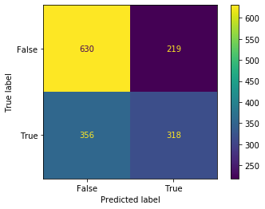

```python
from sklearn import metrics
import matplotlib.pyplot as plt


confusion_matrix = metrics.confusion_matrix(y_test, predictions)
cm_display = metrics.ConfusionMatrixDisplay(confusion_matrix = confusion_matrix, display_labels = [False, True])

cm_display.plot()
plt.show()
```

**Question 7**

Which information are we observing from the confusion matrix?

**Answer 7**

Let's try to use our TF-IDF representation to perform classification and compare the results with the previous one:

```python
k = 5
start_time = time.time()
faissobj = FaissKNNImpl(k,faiss)
faissobj.fitModel(X_train_vectors_tfidf.todense(),y_train)
run_time = time.time() - start_time
print('time required for training %d data points at k = %d: %.2f seconds' % (X_train_vectors_tfidf.shape[0], k , run_time))
```

```
time required for training 6090 data points at k = 5: 0.40 seconds
```

```python
predictions = faissobj.predict(X_test_vectors_tfidf.toarray())
run_time = time.time() - start_time
print('time required for predicting %d data point at k = %d: %.2f seconds' % (X_test_vectors_w2v.shape[0], k , run_time))
```

```
time required for predicting 1523 data point at k = 5: 1.55 seconds
```

Now, we print the evaluation report:

```python
print(classification_report(y_test, predictions))
```

```
              precision    recall  f1-score   support

           0       0.80      0.50      0.62       849
           1       0.57      0.84      0.68       674

    accuracy                           0.65      1523
   macro avg       0.69      0.67      0.65      1523
weighted avg       0.70      0.65      0.65      1523
```

And show the confusione matrix:

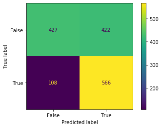

```python
confusion_matrix = metrics.confusion_matrix(y_test, predictions)
cm_display = metrics.ConfusionMatrixDisplay(confusion_matrix = confusion_matrix, display_labels = [False, True])

cm_display.plot()
plt.show()
```

**Question 8**

Comparing the performance with the previous one, what can we say about the TF-IDF Bag-of-Words representation?

**Answer 8**

Let's try another classifier. We will use a Multinomial Naive Bayes classifier:

```python
nb = MultinomialNB()
nb.fit(X_train_vectors_tfidf, y_train)
```

```
MultinomialNB()
```

We obtain predictions as reported in the following:

```python
predictions = nb.predict(X_test_vectors_tfidf)
```

Now, we print the classification report

```python
print(classification_report(predictions, y_test))
```

```
              precision    recall  f1-score   support

           0       0.90      0.76      0.82      1005
           1       0.64      0.83      0.72       518

    accuracy                           0.78      1523
   macro avg       0.77      0.80      0.77      1523
weighted avg       0.81      0.78      0.79      1523
```

and the confusion matrix:

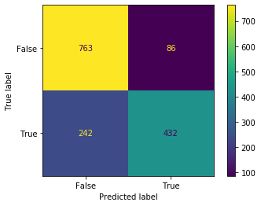

```python
confusion_matrix = metrics.confusion_matrix(y_test, predictions)
cm_display = metrics.ConfusionMatrixDisplay(confusion_matrix = confusion_matrix, display_labels = [False, True])

cm_display.plot()
plt.show()
```

We saw that changing the classifier and using the Bag-of-words TF-IDF representation we improve performance respect to the KNN using the same representation.

# References

- Documentazione di FAISS. https://faiss.ai/index.html
- NLTK documentation: https://www.nltk.org/
- scikit-learn Naive Bayes: https://scikit-learn.org/stable/modules/naive_bayes.html